# NLP capstone project

Anton Mishchuk

10/26/2017

## Summary

The idea of the project is creating an application that can predict the next word in a phrase. There are three sets of sentences given: “twitter”, “blogs” and “news”. Given that data, we need create a prediction model.

The first milestone is about getting and cleaning data, and do basic exploratory analysis. What I’ve done by now:

1. Cleaned the data: filtered sentences, removed punctuation, downcased words, etc.
2. Extracted ngrams from datasets
3. Built frequency diagram for 1, 2, 3, and 5-grams

One can find the code [here](https://github.com/antonmi/nlp_capstone_project).

Please, see details below.

## Data

### Raw data

Let’s take a look at the data we have #### en_US.twitter.txt

```r
con <- file('en_US/en_US.twitter.txt')
raw_lines <- readLines(con, n=5)
close(con)
raw_lines
```

```
## [1] "How are you? Btw thanks for the RT. You gonna be in DC anytime soon? Love to see you. Been way, way too long."
## [2] "When you meet someone special... you'll know. Your heart will beat more rapidly and you'll smile for no reason."
## [3] "they've decided its more fun if I don't."
## [4] "So Tired D; Played Lazer Tag & Ran A LOT D; Ughh Going To Sleep Like In 5 Minutes ;)"
## [5] "Words from a complete stranger! Made my birthday even better :)"
```

Lots of punctuation marks, abbrivations, different case. If we are going to create a set on ngrams from the text data we definitely need to clean the data.

### Data pre-processing

There are few steps of data cleaning:

- Exrtact sentences. I used “[\w\s’]+” regexp to to so. The only non-word character is apostrophe (to handle words like “I’m”). I decided to keep all the rest punctuation marks as sentence delimiter. Hope, it is a good idea, at least at the very beginning
- Downcase all the words in sentences.

The code of “filter_sentences” function is below:

```r
filter_sentences <- function(raw_lines, sentences_path) {
  con <- file(sentences_path, 'w')
  for (line in raw_lines) {
    ss <- str_match_all(line, "[\\w\\s']+")
    ss <- unlist(ss)
    ss <- lapply(ss, trimws)
    ss <- lapply(ss, tolower)
    ss <- ss[lapply(ss, nchar) > 0]
    write(unlist(ss), con, append = TRUE)
  }
  close(con)
}
```

The sentences are saved into separate files: “twitter_sentences.txt”, “blogs_sentences.txt”, “news_sentences.txt”.

## Exploratory analysis

### Building ngrams

For each set of sentences I’ve built a sets of ngrams, from one-grams to ten-grams. I’m not really sure that we need ten-words-grams, but let’s do it for now.

The code of “ngrams” function:

```r
ngrams <- function(str, n) {
  ws <- words(str)
  word_count <- length(ws)
  if (word_count < n) { return(NULL) }
  if (word_count == n) { return(str) }

  result <- NULL
  for (i in c(1:(word_count-n+1))) {
    result <- c(result, paste(ws[i:(i+n-1)], collapse = ' '))
  }
  result
}
```

I’ve used “parallel” library to run ngrams creation in parallel using all processor cores.

After ngrams being built I’ve calculated corresponding frequencies. In order to decrease size of files I saved ngrams that have frequency grater than or equal 5. There is no specific reason for choosing 5 for now, I just wanna filter statistically signifact ngrams and decrease a size of files.

After all the pre-processing 30 relatevely small files (couple of MB each) are created - 10 files for each dataset (“twitters”, “news”, “blogs”). Each file has a list of ngrams with their frequencies.

For example, below are first 10 lines of 5-gram for every set:

| twitter | blogs | news |
| --- | --- | --- |
| thank you so much for | at the end of the | at the end of the |
| thanks for the shout out | in the middle of the | for the first time in |
| can’t wait to see you | the end of the day | for the first time since |
| let me know if you | for those of you who | by the end of the |
| at the end of the | for the first time in | in the middle of the |
| thanks so much for the | the other side of the | the end of the day |
| thank you for the follow | by the end of the | the end of the year |
| i love you so much | for the rest of the | at the time of the |
| is going to be a | there are a lot of | there are a lot of |
| keep up the good work | i thought it would be | the dow jones industrial average |

Twitter has very positive ngrams in the top! Blogs and news have general expressions about time and place.

### Analysing ngrams

Let’s perform detailed ngrams analysis on the most positive - “twitter” - dataset.

```r
twitter_1 <- read.csv('data/ngrams/twitter_ngrams1.txt')
dim(twitter_1)
```

```
## [1] 75559     2
```

So, there are 75559 words in our dataset. Remember that we filtered words with the frequency greater than or equal to 5.

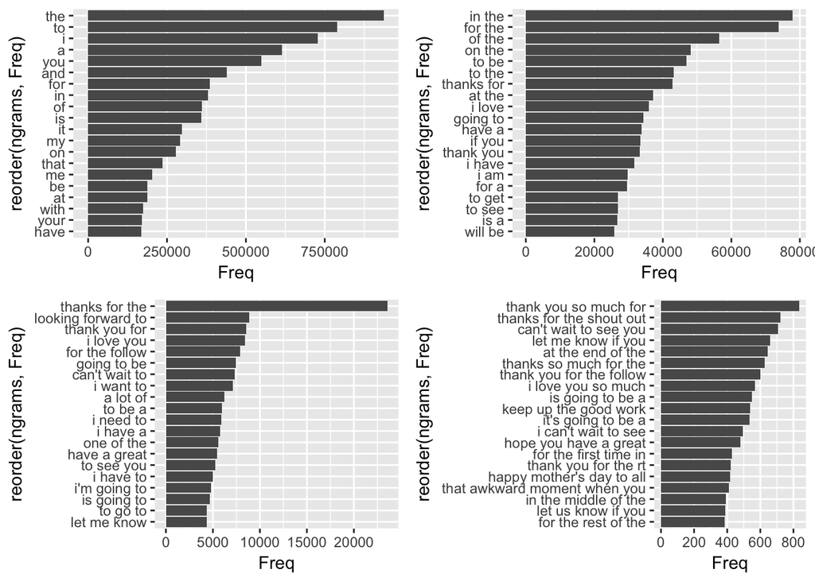

If we do the same plots for “blogs” set, we will see this:

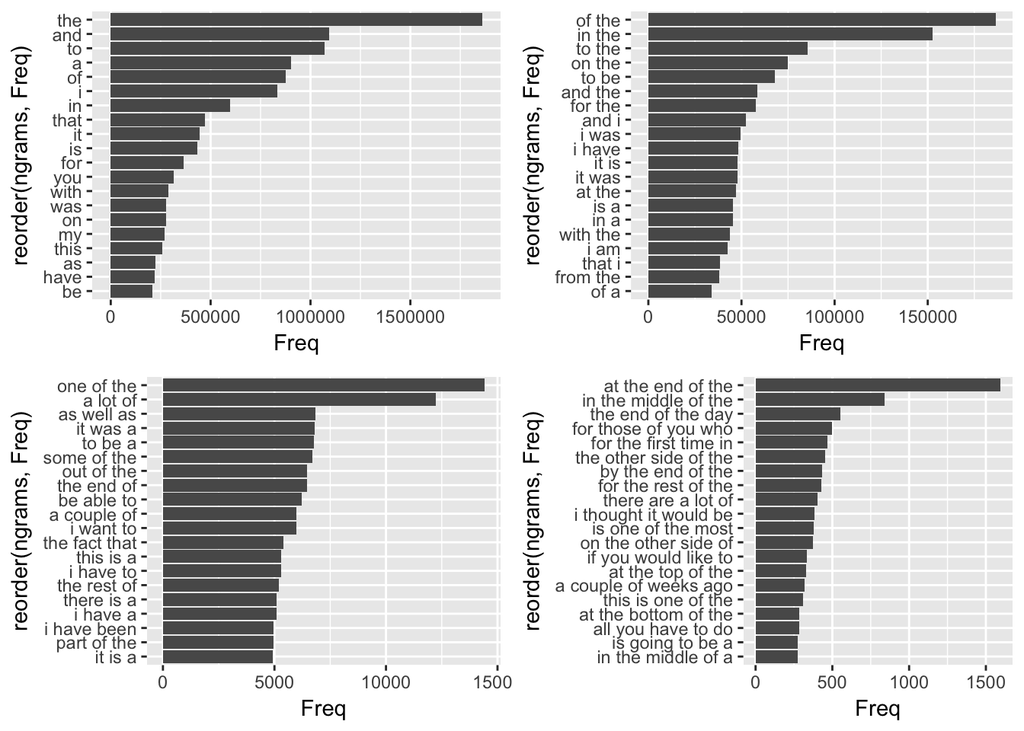

And for ‘news’ set:

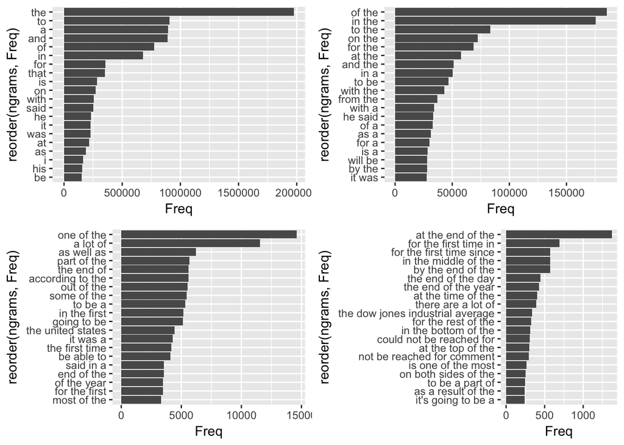